# Predicting next word in user input

Igor Basov  
December 28, 2015

### Description

This app predicts next word in user input based on it’s probability calculated from training documents.

This app uses data obtained from HC Corpora (www.corpora.heliohost.org) to build prediction algorithm.

It uses Markov approximation and simple backoff model to make predictions.

App implements a tradeoff between memory and speed efficiency at one side and correctness of predictions at another.

### App structure

App consists of side panel and main panel.

- Side panel allows you to input a sentence or some words for program to predict next word.
- Predict button launches working algorithm to make prediction for your input.
- Main panel shows you three most probable words that seem to be the continuation of your input.

### Algorithm description

Basing on Markov approximation app uses n-grams obtained from training corpus to predict next word.

App uses up to 3 degree of n-grams, because higher degrees cost much memory and take away a lot of efficiency.

Basic steps:

- Find 3-grams with first two words being equal to last two words of the input, show 3 most common last words. If it's not there, go to the next step
- Find 2-grams with first word being equal to last word of the input, show 3 most common last words. If it's not there, go to the next step
- Show 3 most common words

### Example

This is an example of how application works.

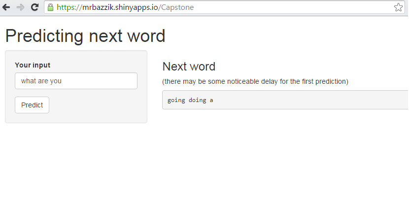

Having entered “what are you” in the input filed and pressed “Predict” you’re shown 3 most probable words in descending order.